# DDD plots

Matthew Stephens

2016-10-25

**Last updated:** 2017-01-15

**Code version:** b05decc05714ddcb20aa04e56b557d5123d178fb

This file produces ``meta-analysis" style plots that illustrate the shrinkage behaviour of ash on some simple simulated data.

First, we load the necessary libraries.

```r
library(knitr)
library(rmeta)
library(ashr)
```

## Simulate Data

We simulate 50 effects ($\beta$), half of which are truly “null” (ie 0) and the other half are $N(0,2^2)$. The observed effects ($\hat\beta$) all have standard error 1 here.

```r
set.seed(1)
n        = 50
beta     = c(rep(0,n/2),rnorm(n/2,0,2))
betahat  = beta + rnorm(n)
beta.ash = ash(betahat,1)
```

## Meta Plots

Here we plot the standard Confidence Intervals, ordered by the observed effect sizes. The red colors indicate observations corresponding to effects that were truly 0.

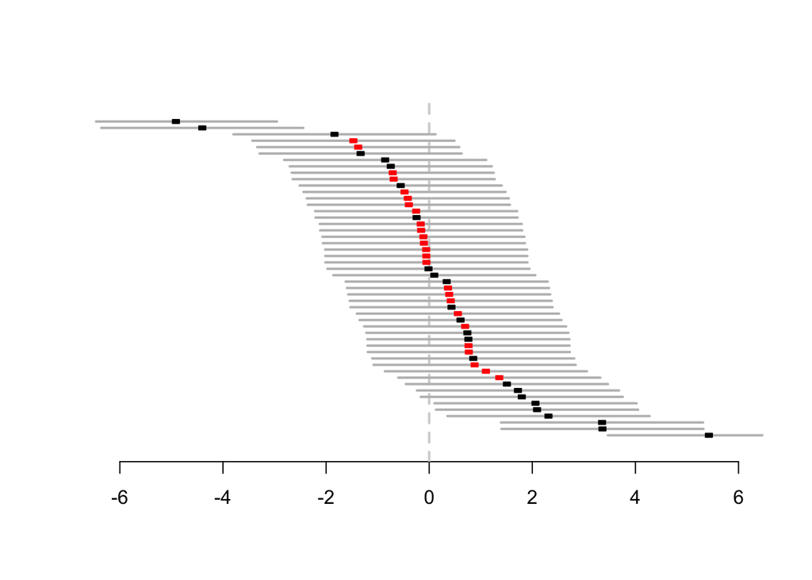

```r
i = order(betahat)
metaplot(betahat[i],rep(1,n),ylab = "",xlab = "",xlim = c(-6,6),
         colors = meta.colors(box = c(rep("red",n/2),rep("black",n/2))[i]))
```

Here we plot the *shrunken* Confidence Intervals (more formally, posterior Credible Intervals), in the same order, with same color code. (We use the approximation of the posterior mean $\pm$ 2 posterior standard deviation; really we should compute the posterior intervals using `ashci`, but this simple approximation suffices for illustrating the idea.)

Notice how the CIs are strongly shrunk towards 0, except for those that correspond to large effects, where the shrinkage is more modest. What is happening here is that ash recognizes that although many effects are null, others are quite big, so it avoids shrinking too much the intervals whose data are sufficiently strong to convince it that they are non-null.

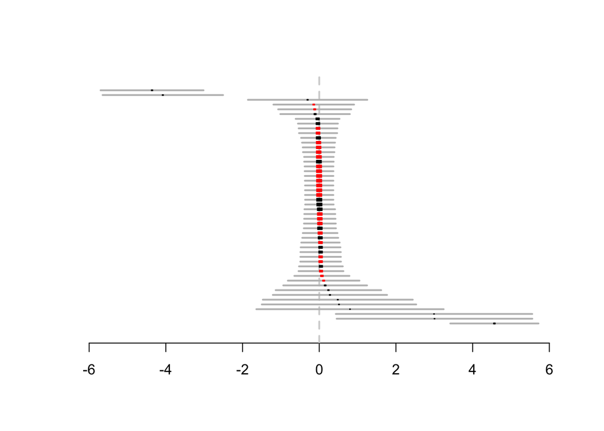

```r
metaplot(get_pm(beta.ash)[i],get_psd(beta.ash)[i],
         ylab = "",xlab = "",xlim = c(-6,6),
         colors = meta.colors(box = c(rep("red",n/2),rep("black",n/2))[i]))
```